# Statistics

Describing statistical methods

Statistics

Author

Łukasz Rąbalski

## 1 Logistic Regression

inspirations: [url](https://quantifyinghealth.com/interpret-logistic-regression-intercept/) [url](https://quantifyinghealth.com/interpret-logistic-regression-coefficients/)

| Survived | independent |
| --- | --- |
| 0 | 1.945910 |
| 1 | 4.262680 |
| 1 | 2.079442 |
| 1 | 3.970292 |
| 0 | 2.079442 |
| 0 | 2.079442 |

Table 1. Summary statistics for logistic regression model

| term | estimate | std.error | statistic | p.value |
| --- | --- | --- | --- | --- |
| (Intercept) | -2.6623408 | 0.2493139 | -10.678668 | 0 |
| independent | 0.7429505 | 0.0798121 | 9.308746 | 0 |

### 1.1 Matematyczna interpretacja modelu

### 1.2 equation

Here’s the equation of a logistic regression model with 1 predictor X:

$log(\frac{P}{1-P})=\beta_0 + \beta_1X$

Where: *P* is the probability of having the outcome $\frac{P}{1-P}$ is the odds of the outcome. Left side called *log odds* or *logit* and P / (1-P) is the odds of the outcome. $\beta_0$ called intercept

### 1.3 From log odds to probability

To solve for the probability P, we exponentiate both sides of the equation above to get:

`Equation 1`.: $\frac{P}{1-P}= e^{\beta_0 + \beta_1X}$

With this equation, we can calculate the probability P for any given value of X

### 1.4 intercept interpretation

When X = 0 the interpretation of intercept become simple using `Equation 1.` $P=\frac{e^{\beta_0}}{(1 + e^{\beta_0})}$ :

- If the intercept has a negative sign: then the probability of having the outcome will be < 0.5.
- If the intercept has a positive sign: then the probability of having the outcome will be > 0.5.
- If the intercept is equal to zero: then the probability of having the outcome will be exactly 0.5.

So in case of my log model

```r
print(coef(model)[1])
```

```
(Intercept)
  -2.662341
```

```r
prob_of_survival<-round(exp(coef(model)[1])/(1+exp(coef(model)[1])),2)
print(paste0('according to model probability of surving the trip if the independent  variable was = 0 is: ',prob_of_survival))
```

```
[1] "according to model probability of surving the trip if the independent  variable was = 0 is: 0.07"
```

### 1.5 estimate interpretation

`Remember`, the coefficient in a logistic regression model is the expected increase in the log odds given a one unit increase in the explanatory variable.

```r
#Tak przemnozone wspolczynniki interpretujemy nastepujaco:
#  o ile % wzrosnie odds wystapienia zdarzenia jezeli wzrosnie nam wartosc predyktora o 1
exp(coef(model))
```

```
(Intercept) independent
 0.06978468  2.10212868
```

Ponizej w sposob matematyczny pokazuje ze to wlasnie oznacza interpretacja wzrostu parametra stajacego przy predyktorze.

```r
df_aug <- augment(model, type.predict = "response") # without response argument, the fitted value will be on log-odds scale

p1 = df_aug$.fitted[df_aug$independent==1][1]
p2 = df_aug$.fitted[df_aug$independent==2][1]

x <- round(p2/(1-p2)/(p1/(1-p1)),5)

# i sprawdzenie czy dobrze rozumiem zależnosc
x1<-round(exp(coef(model))['independent'],5)
x1==x
```

```
independent
         NA
```

**`Quiz`**

The fitted coefficient from the medical school logistic regression model is 5.45. The exponential of this is 233.73.

Donald’s GPA is 2.9, and thus the model predicts that the probability of him getting into medical school is 3.26%. The odds of Donald getting into medical school are 0.0337, or—phrased in gambling terms—29.6:1. If Donald hacks the school’s registrar and changes his GPA to 3.9, then which of the following statements is FALSE:

Possible Answers

Correct answers on the bottom of the page.

### 1.6 Graficzna interpretacja modelu

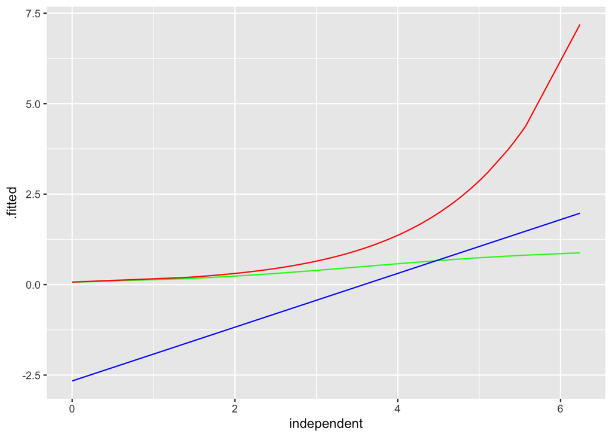

```r
df_aug %>% mutate(Survived_hat=round(.fitted)) %>%
  select(Survived, Survived_hat) %>% table
```

```
        Survived_hat
Survived   0   1
       0 470  75
       1 219 123
```

```r
#Out of sample predictions
DiCaprio<-data.frame(independent=1)
augment(model, newdata = DiCaprio, type.predict = 'response')
```

```
# A tibble: 1 × 2
  independent .fitted
        <dbl>   <dbl>
1           1   0.128
```

### 1.7 stepwise

In order to run stepwise regression you should use library SignifReg.

SignifReg selects only significant predictors according to a designated criterion. More to be find [url](https://cran.r-project.org/web/packages/SignifReg/SignifReg.pdf)

Method based on AIC criterion not basing on significance of predictors to be found here [url](https://quantifyinghealth.com/stepwise-regression-in-r/)

```r
library(SignifReg)
dep_var_temp = 'Survived'

fullmodel = glm(paste0(dep_var_temp," ~ ."), family = 'binomial', data = df_titanic %>% select(-Name)) # model with all variables
nullmodel = glm(paste0(dep_var_temp," ~ 1"), family = 'binomial', data = df_titanic) # model with the intercept only

scope = list(lower=formula(nullmodel),upper=formula(fullmodel))
fit1 <- nullmodel
select.fit = SignifReg(fit1, scope = scope, direction = "forward", trace = FALSE)


broom::tidy(select.fit) %>%
  mutate(dep_var=dep_var_temp) %>% rename(indep_var=term) %>%  dplyr::select(dep_var,indep_var, everything()) %>%
  mutate_if(is.numeric, round, digits=2) %>% rename(t.statistic=statistic) %>%
  mutate(`exp_(estimate)`=ifelse(indep_var!='(Intercept)',exp(estimate),NA)) %>%
  relocate(`exp_(estimate)`,.after=estimate)
```

```
# A tibble: 6 × 7
  dep_var  indep_var               estimate exp_(estim…¹ std.e…² t.sta…³ p.value
  <chr>    <chr>                      <dbl>        <dbl>   <dbl>   <dbl>   <dbl>
1 Survived (Intercept)                 4.03      NA         0.82    4.91    0
2 Survived Sexmale                    -2.67       0.0693    0.2   -13.5     0
3 Survived Pclass                     -1.01       0.364     0.17   -6.03    0
4 Survived Age                        -0.04       0.961     0.01   -5.65    0
5 Survived Siblings.Spouses.Aboard    -0.53       0.589     0.12   -4.41    0
6 Survived independent                 0.33       1.39      0.14    2.31    0.02
# … with abbreviated variable names ¹`exp_(estimate)`, ²std.error, ³t.statistic
```

## 2 Bayesian Statistics - Introduction

### 2.1 Introduction

The role of probability distributions in Bayesian data analysis is to represent uncertainty, and the role of Bayesian inference is to update these probability distributions to reflect what has been learned from data.

Let say I want to set an advertisement on social media. They claim, adds on their surface has 10% of clicks. I a bit sceptical and asses probable efectivnes may range between 0 and 0.20. I assume that binomial model will imitate process generating visitors. Binomial model is my generative model then.

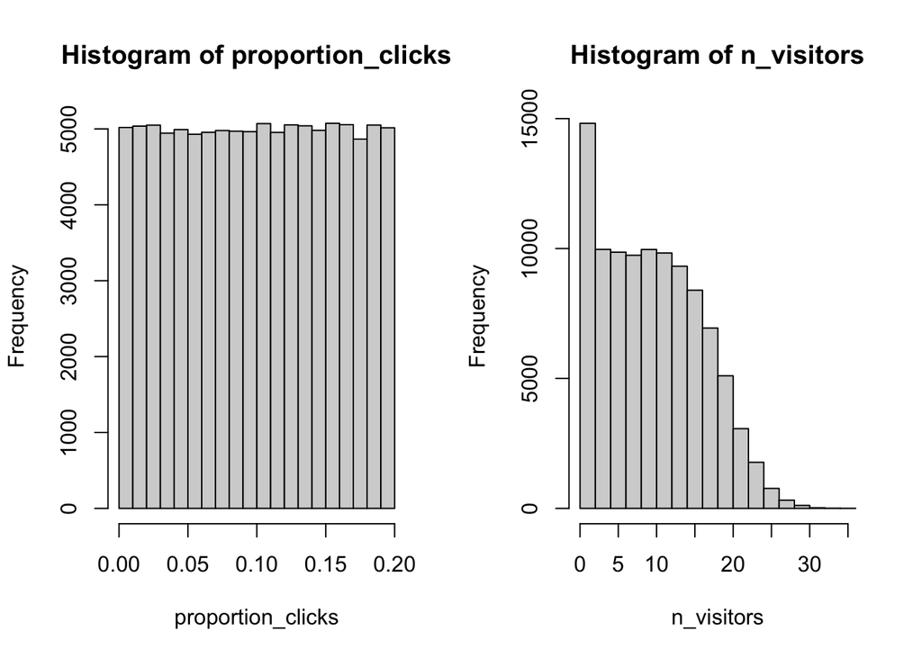

```r
n_samples <- 100000
n_ads_shown <- 100
proportion_clicks <- runif(n_samples, min = 0.0, max = 0.2)
n_visitors <- rbinom(n = n_samples, size = n_ads_shown, prob = proportion_clicks)

par(mfrow=c(1,2))
# Visualize proportion clicks
hist(proportion_clicks)
# Visualize n_visitors
hist(n_visitors)
```

Below I present joint distribution over both the underlying proportion of clicks and how many visitors I would get.

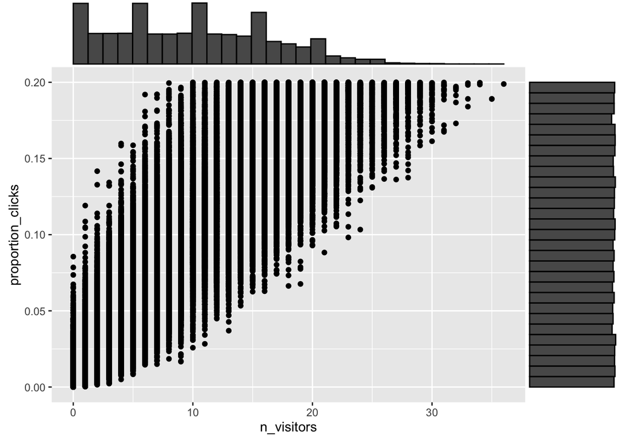

I ran my ad campaign, and 13 people clicked and visited your site when the ad was shown a 100 times. I would now like to use this new information to update the Bayesian model. The reason that we call it posterior is because it represents the uncertainty after (that is, posterior to) having included the information in the data.

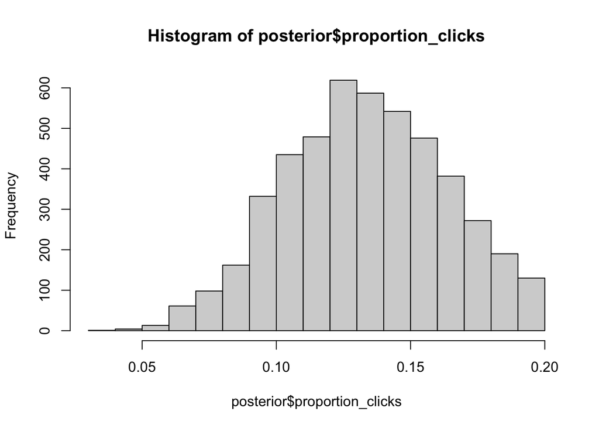

```r
# Create the posterior data frame
posterior <- prior[prior$n_visitors == 13, ]

# Visualize posterior proportion clicks - below I condition the joint distribution - of prior distribution of proportion_clicks and distribution of n_visitors
hist(posterior$proportion_clicks)
```

Now we want to use this updated proportion_clicks to predict how many visitors we would get if we reran the ad campaign.

```r
# Assign posterior to a new variable called prior
prior <- posterior

# Take a look at the first rows in prior
head(prior)
```

```
   proportion_clicks n_visitors
10         0.1973504         13
22         0.1555724         13
66         0.1213712         13
68         0.1366464         13
93         0.1340447         13
96         0.1325997         13
```

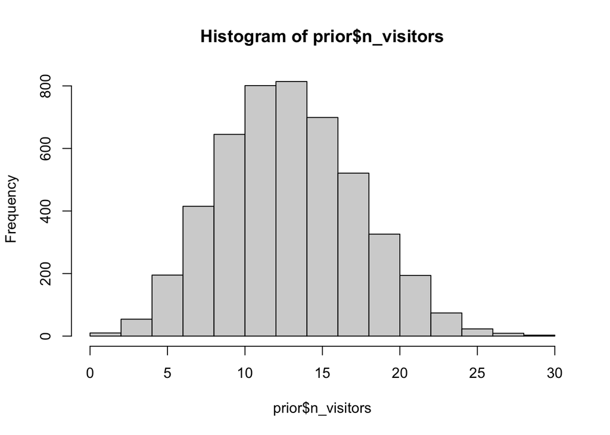

```r
# Replace prior$n_visitors with a new sample and visualize the result
n_samples <-  nrow(prior)
n_ads_shown <- 100
prior$n_visitors <- rbinom(n_samples, size = n_ads_shown, prob = prior$proportion_clicks)
hist(prior$n_visitors)
```

### 2.2 Priors

#### 2.2.1 Beta distribution

The Beta distribution is a useful probability distribution when you want model uncertainty over a parameter bounded between 0 and 1. Here you’ll explore how the two parameters of the Beta distribution determine its shape.

So the larger the shape parameters are, the more concentrated the beta distribution becomes.

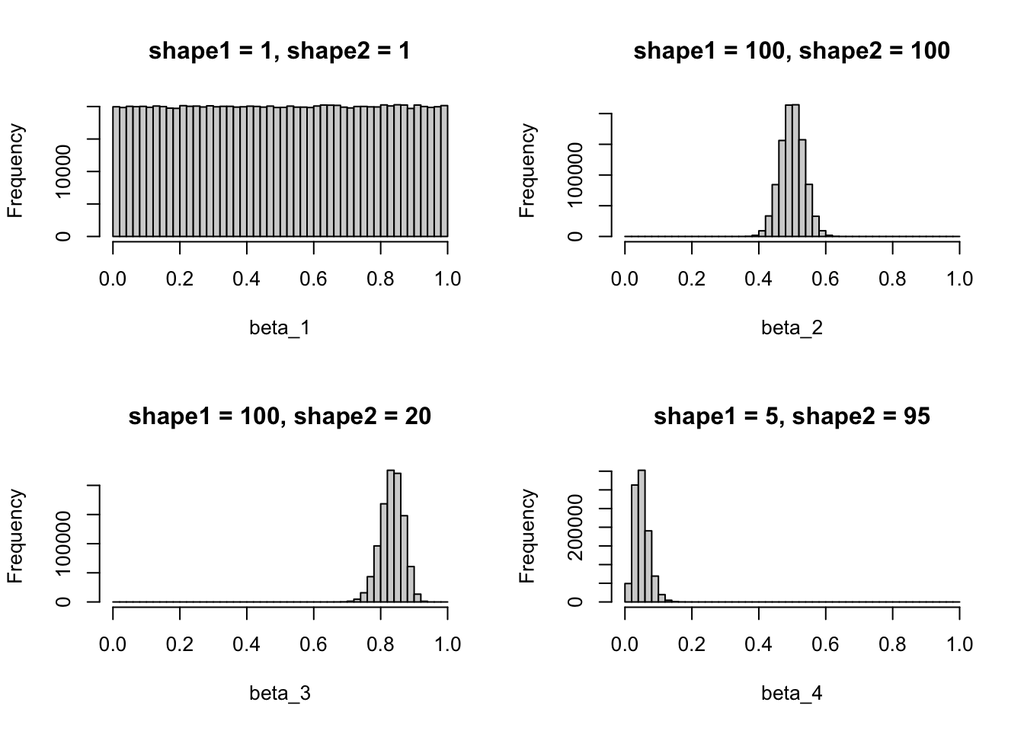

```r
# Explore using the rbeta function
beta_1 <- rbeta(n = 1000000, shape1 = 1, shape2 = 1)
beta_2 <- rbeta(n = 1000000, shape1 = 100, shape2 = 100)
beta_3 <- rbeta(n = 1000000, shape1 = 100, shape2 = 20)
beta_4 <- rbeta(n = 1000000, shape1 = 5, shape2 = 95)



par(mfrow=c(2,2))
hist(beta_1, breaks=seq(0,1,0.02), main = "shape1 = 1, shape2 = 1")
hist(beta_2, breaks=seq(0,1,0.02), main = "shape1 = 100, shape2 = 100")
hist(beta_3, breaks=seq(0,1,0.02), main = "shape1 = 100, shape2 = 20")
hist(beta_4, breaks=seq(0,1,0.02), main = "shape1 = 5, shape2 = 95")
```

The 4th graphs represents the best following setence: *Most ads get clicked on 5% of the time, but for some ads it is as low as 2% and for others as high as 8%.*

### 2.3 Contrasts and comparison

Let say, I initialize also text add campaign, get 6 visitors out of 100 views and now I want to compare which one video or text add is more cost effective.

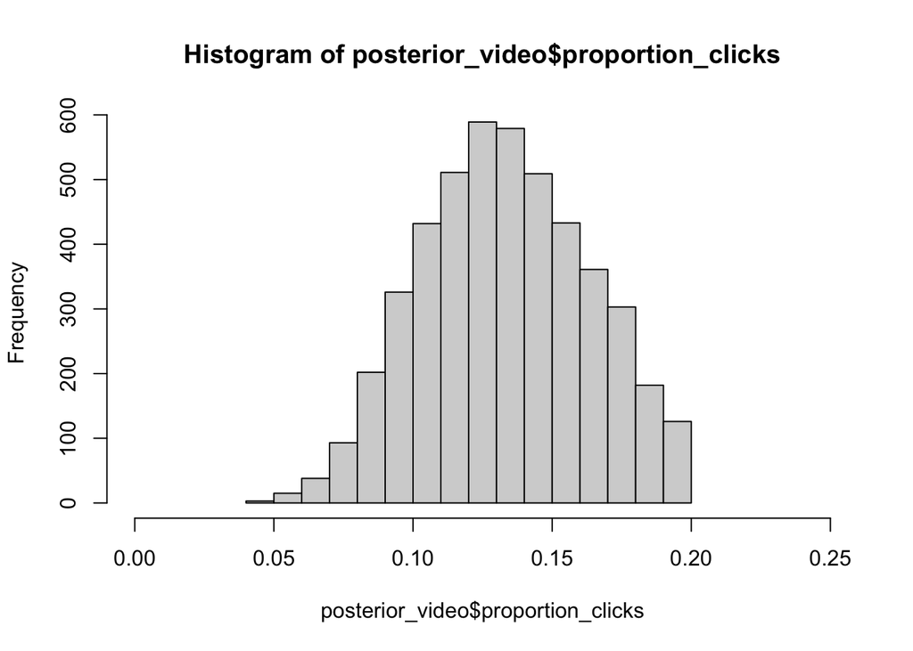

```r
# Define parameters
n_draws <- 100000
n_ads_shown <- 100
proportion_clicks <- runif(n_draws, min = 0.0, max = 0.2)
n_visitors <- rbinom(n = n_draws, size = n_ads_shown,
                     prob = proportion_clicks)
prior <- data.frame(proportion_clicks, n_visitors)

# Create the posteriors for video and text ads
posterior_video <- prior[prior$n_visitors == 13, ]
posterior_text <- prior[prior$n_visitors == 6, ]

# Visualize the posteriors
hist(posterior_video$proportion_clicks, xlim = c(0, 0.25))
```

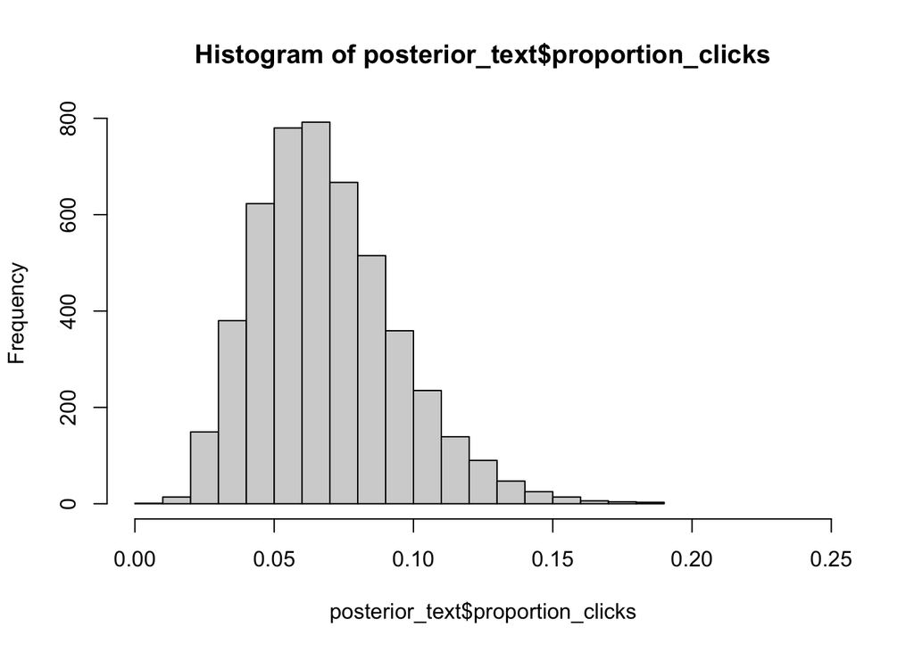

```r
hist(posterior_text$proportion_clicks, xlim = c(0, 0.25))
```

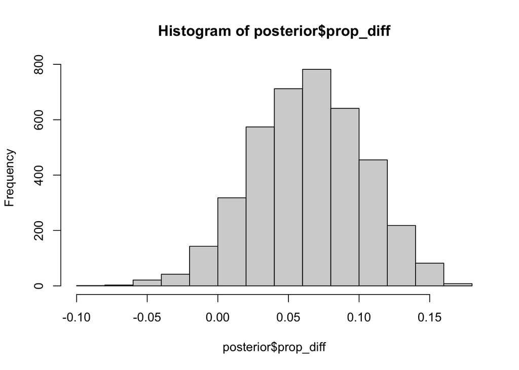

```r
posterior <- data.frame(video_prop = posterior_video$proportion_clicks[1:4000],
                        text_prop = posterior_text$proportion_click[1:4000])

# Calculate the posterior difference: video_prop - text_prop
posterior$prop_diff <- posterior$video_prop - posterior$text_prop

# Visualize prop_diff
hist(posterior$prop_diff)
```

```r
# Calculate the median of prop_diff
median(posterior$prop_diff)
```

```
[1] 0.0647875
```

```r
# Calculate the proportion
mean(posterior$prop_diff > 0.0)
```

```
[1] 0.9475
```

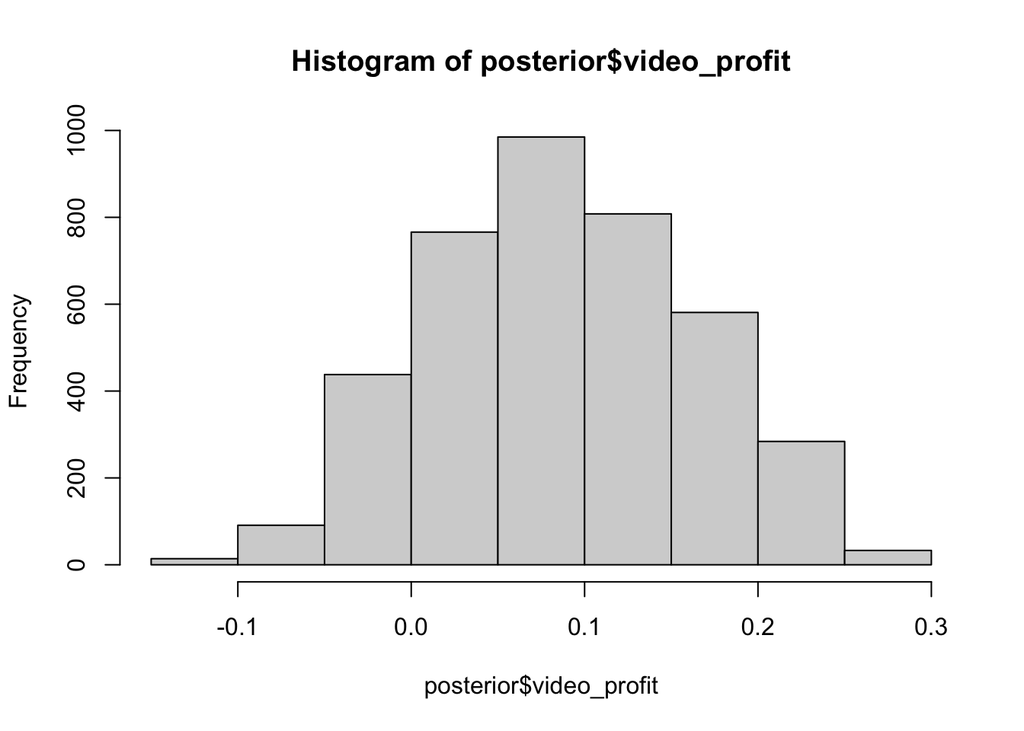

```r
#Different adds have differnt costs then:
visitor_spend <- 2.53
video_cost <- 0.25
text_cost <- 0.05

# Add the column posterior$video_profit
posterior$video_profit <- posterior$video_prop * visitor_spend - video_cost

# Add the column posterior$text_profit
posterior$text_profit <- posterior$text_prop * visitor_spend - text_cost

# Visualize the video_profit and text_profit columns
hist(posterior$video_profit)
```

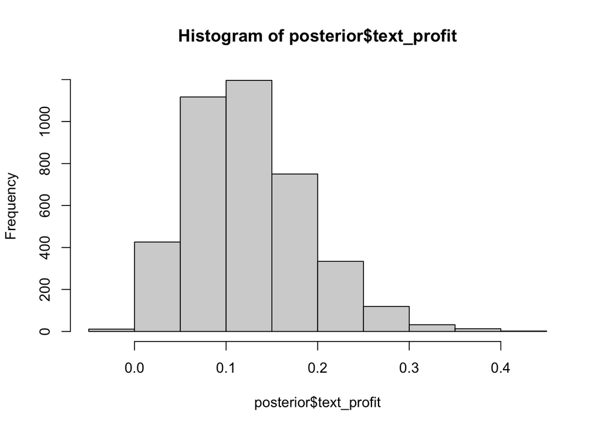

```r
hist(posterior$text_profit)
```

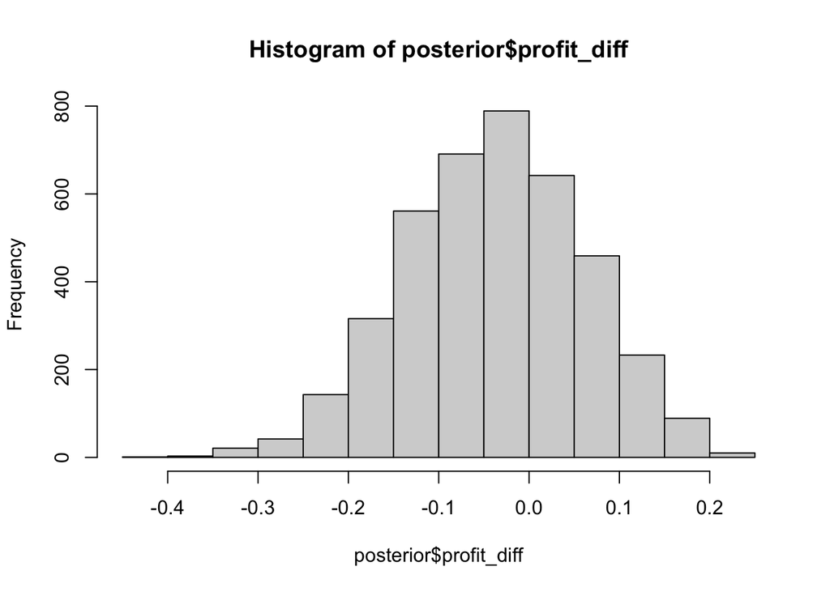

```r
# Add the column posterior$profit_diff
posterior$profit_diff <- posterior$video_profit - posterior$text_profit

# Visualize posterior$profit_diff
hist(posterior$profit_diff)
```

```r
# Calculate a "best guess" for the difference in profits
median(posterior$profit_diff)
```

```
[1] -0.03608763
```

```r
# Calculate the probability that text ads are better than video ads
mean(posterior$profit_diff < 0)
```

```
[1] 0.64175
```

```r
#So it seems that the evidence does not strongly favor neither text nor video ads. But if forced to choose the text ads is better.
```

#### 2.3.1 Changeing Generative model

Company has changed the way how they price adds. Now they take money just for full day of exposition. Binomial model, which approximate participation of succes in all trials (click in all views) is no longer valid. For new scenario. **Poison distribution** is now needed.

**The Poison distribution takes only one parameter which is the mean number of events per time unit**

In R you can simulate from a Poisson distribution using rpois where lambda is the average number of occurrences:

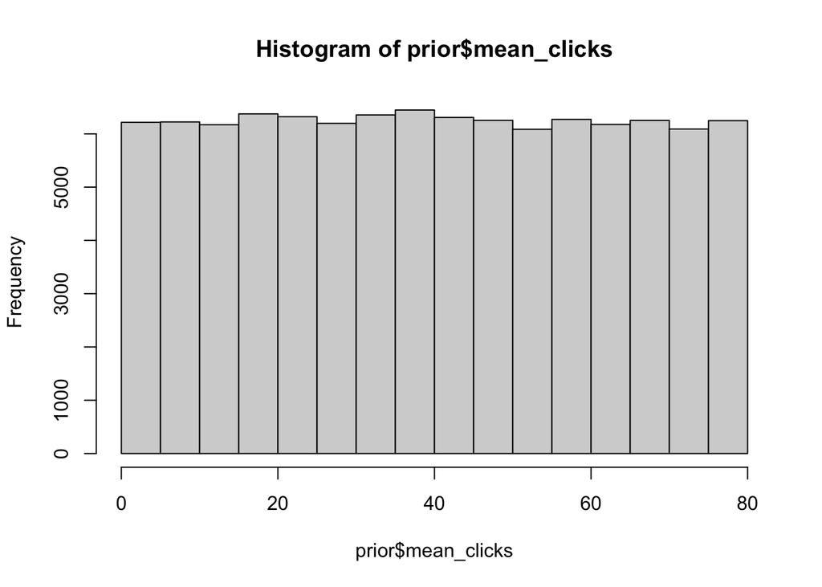

```r
# Change the model according to instructions
n_draws <- 100000
mean_clicks <- runif(n_draws, min = 0, max = 80) #this is my prior
n_visitors <- rpois(n = n_draws, mean_clicks)

prior <- data.frame(mean_clicks, n_visitors)
posterior <- prior[prior$n_visitors == 19, ]

hist(prior$mean_clicks)
```

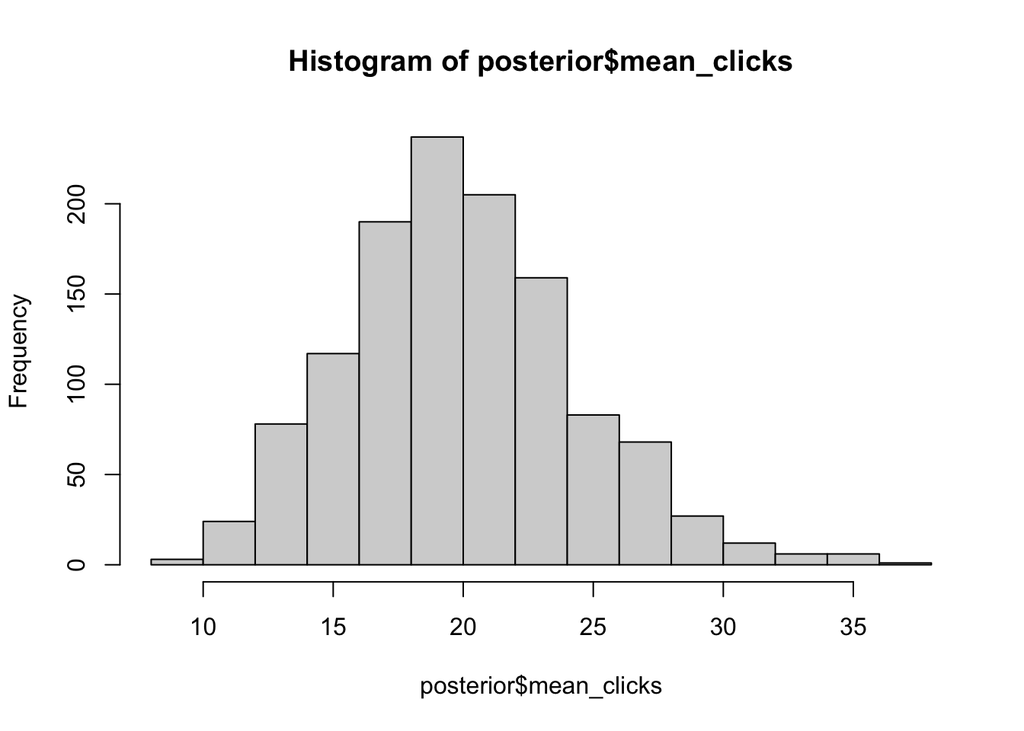

```r
hist(posterior$mean_clicks)
```

### 2.4 Dealing with 2 parameter model

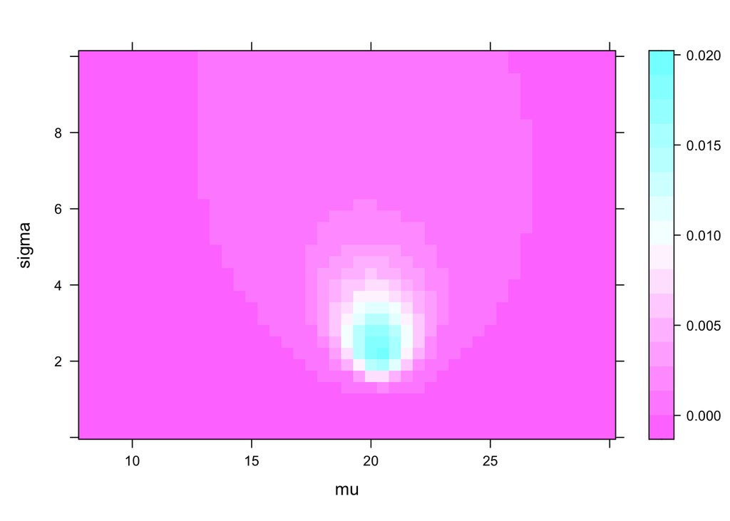

```r
#  the temperatures of Sweden water in 21 th of June in few following year
temp <- c(19,23,20,17,23)
# Defining the parameter grid - here are are my priors about the posible values of parameters of distribution
pars <- expand.grid(mu = seq(8,30, by = 0.5),
                    sigma = seq(0.1, 10, by= 0.3))
# Defining and calculating the prior density for each parameter combination
pars$mu_prior <- dnorm(pars$mu, mean = 18, sd = 5)
pars$sigma_prior <- dunif(pars$sigma, min = 0, max = 10)
pars$prior <- pars$mu_prior * pars$sigma_prior
# Calculating the likelihood for each parameter combination
for(i in 1:nrow(pars)) {
  likelihoods <- dnorm(temp, pars$mu[i], pars$sigma[i])
  pars$likelihood[i] <- prod(likelihoods)
}
# Calculate the probability of each parameter combination
pars$probability <- pars$likelihood * pars$prior
pars$probability <- pars$probability / sum(pars$probability )

library(lattice)
levelplot(probability ~ mu * sigma, data = pars)
```

Right now the posterior probability distribution is represented as a data frame with one row per parameter combination with the corresponding probability.

```r
head(pars)
```

```
    mu sigma   mu_prior sigma_prior       prior likelihood probability
1  8.0   0.1 0.01079819         0.1 0.001079819          0           0
2  8.5   0.1 0.01312316         0.1 0.001312316          0           0
3  9.0   0.1 0.01579003         0.1 0.001579003          0           0
4  9.5   0.1 0.01880982         0.1 0.001880982          0           0
5 10.0   0.1 0.02218417         0.1 0.002218417          0           0
6 10.5   0.1 0.02590352         0.1 0.002590352          0           0
```

But my questions are much easier to answer if the posterior is represented as a large number of samples, like in earlier chapters. So, let’s draw a sample from this posterior.

```r
sample_indices <- sample(1:nrow(pars), size=10000, replace=TRUE, prob=pars$probability)
pars_sample <- pars[sample_indices,c("mu","sigma")]
head(pars_sample)
```

```
      mu sigma
252 21.0   1.6
793 21.5   5.2
519 19.5   3.4
518 19.0   3.4
341 20.5   2.2
296 20.5   1.9
```

What is probabibility of temperature being 18 or above? Not mean temperature, the actual temperature.

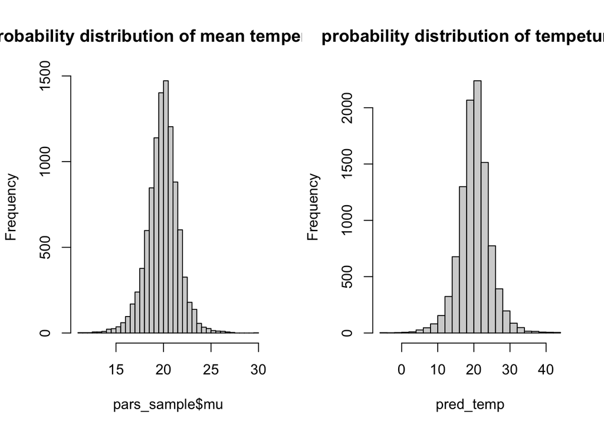

```r
#rnorm is vectorized and implicitly loops over mu and sigma
pred_temp<- rnorm(10000, mean=pars_sample$mu, sd=pars_sample$sigma)

par(mfrow=c(1,2))
hist(pars_sample$mu,30, main = 'probability distribution of mean temperature')
hist(pred_temp,30, main = 'probability distribution of tempeture' )
```

```r
mean(pred_temp>=18)
```

```
[1] 0.7366
```

### 2.5 Automatisation - BEST package

The Bayesian model behind BEST assumes that the generative model for the data is a t-distribution; a more flexible distribution than the normal distribution as it assumes that data points might be outliers to some degree. This makes BEST’s estimate of the mean difference robust to outliers in the data.

The t-distribution is just like the normal distribution, a generative model with a mean and a standard deviation that generates heap shaped data. The difference is that the t-distribution has an extra parameter, sometimes called the degrees-of-freedom parameter, that governs how likely the t-distribution is to generate outliers far from its center.

Another way in which BEST is different is that BEST uses a so-called Markov chain Monte Carlo method to fit the model. Markov chain Monte Carlo, or MCMC for short, returns a table of samples from the posterior, we can work with the output just like before.

```r
# The IQ of zombies on a regular diet and a brain based diet.
iq_brains <- c(44, 52, 42, 66, 53, 42, 55, 57, 56, 51)
iq_regular <- c(55, 44, 34, 18, 51, 40, 40, 49, 48, 46)

# Calculate the mean difference in IQ between the two groups
mean(iq_brains) - mean(iq_regular)

# Fit the BEST model to the data from both groups
library(BEST)
library(rjags)
best_posterior <- BESTmcmc(iq_brains, iq_regular)

# Plot the model result
plot(best_posterior)
```

[output not shown]

Assume that a super smart mutant zombie (IQ = 150) got into the iq_regular group by mistake. This might mess up the results as you and your colleagues really were interested in how diet affects normal zombies.

```r
# The IQ of zombies given a regular diet and a brain based diet.
iq_brains <- c(44, 52, 42, 66, 53, 42, 55, 57, 56, 51)
iq_regular <- c(55, 44, 34, 18, 51, 40, 40, 49, 48,
                150) # <- Mutant zombie

# Modify the data above and calculate the difference in means
mean(iq_brains) - mean(iq_regular)
```

[output not shown]

```r
# Fit the BEST model to the modified data and plot the result
library(BEST)
best_posterior <- BESTmcmc(iq_brains, iq_regular)
plot(best_posterior)
```

[output not shown]

### 2.6 Conclusions

Bayes allows you to tweak, change and tinker with the model to better fit the data analytical problem you have. But a last reason to use Bayes is because it is optimal, kind of. It can be shown, theoretically, that no other method learns as efficiently from data as Bayesian inference.

In above examples I show what Bayesian model is about: * I describe my expectations of proportion_clicks as uniform distribution (prior) * Then i describe a generative model which will be responsible for generating views based on proportion_clicks - the second source of variability. For this aim I use two diffrent distribution - binomial and poison - depending on specifity of exercise. * I was able to say which add wass better, more, I was able to say which add was better in probability way.

## 3 Bayesian Statistics - Intermediate

### 3.1 Likelihood

On the example of poll. Imagine I am taking part in election to local goverment. Based on many historical election poles I can count on 45% of votes. Votes chances are approximate by bheta function.

```r
df<-data.frame(sample=seq(0,1,0.01),
               density=dbeta(x=seq(0,1,0.01),shape1=45,shape2=55))
df %>% ggplot(aes(x=sample,y=density))+
  geom_line()+
  ggtitle("Density function")
```

[output not shown]

Lets imagine that i receive 60% of votes in ellection pole. I can assume that binomial distribution is well suited for generative model responsible for how many votes I am geting. Then I may ask myself: **How probable would be obtaining such a results (60%) of votes under different succes_rate (paramter of Binomial distribution).

```r
df<-data.frame(likelihood=dbinom(x=6,size=10,prob=seq(0,1,0.1)),
               parameter_p=seq(0,1,0.1))

df %>% ggplot(aes(x=parameter_p,y=likelihood))+
  geom_line()+
  ggtitle("Likelihood distribution over different succes_rate parameters")
```

[output not shown]

The likelihood function summarizes the likelihood of observing polling data X under different values of the underlying support parameter p. Thus, the likelihood is a function of p that depends upon the observed data X

### 3.2 Posterior

Since I’ve got the prior & likelihood:

- prior: let say based on the historical pole % of votes I can count on is described by betha distribution Betha(45.55) –> most probable is geting 45% votes
- likelihood: is denoting to the most recent data shown above

I can approach now to modeling **posterior model of p** According to Bayes rules posterior is calculating by:

*posterior* = prior * likelihood

However, in more sophisticated model settings, tidy, closed-form solutions to this formula might not exist. Very loosely speaking, the goal here is to send information out to the JAGS program, which will then design an algorithm to sample from the posterior, based on which I will then simulate the posterior.

#### 3.2.1 Compiling rjags model

```r
library(rjags)

# DEFINE the model
vote_model <- "model{
    # Likelihood model for X
    X ~ dbin(p, n)

    # Prior model for p
    p ~ dbeta(a, b)
}"

# COMPILE the model
vote_jags <- jags.model(textConnection(vote_model),
    data = list(a = 45, b = 55, X = 6, n = 10),
    inits = list(.RNG.name = "base::Wichmann-Hill", .RNG.seed = 100))

# SIMULATE the posterior
vote_sim <- coda.samples(model = vote_jags, variable.names = c("p"), n.iter = 10000)

# PLOT the posterior
plot(vote_sim, trace = FALSE)
```

[output not shown]

Quiz correct answers: d. Hint: `Remember`, the coefficient in a logistic regression model is the expected increase in the log odds given a one unit increase in the explanatory variable.